# EXPLORATORY DATA ANALYSIS

In statistics, exploratory data analysis (EDA) is an approach to analyzing data sets to summarize their main characteristics, often with visual methods.

# IRIS DATASET

The Iris flower data set or Fisher's Iris data set is a multivariate data set introduced by the British statistician and biologist Ronald Fisher in his 1936 paper The use of multiple measurements in taxonomic problems as an example of linear discriminant analysis.

# BASIC TEMINOLOGY

1. EDA
2. DataPoint/Vector/Observation
3. Dataset

# OBJECTIVE

This is perhaps the best known data set to be found in the classification literature. The aim is to classify iris flowers among three species (setosa, versicolor or virginica) from measurements of length and width of sepals and petals.

```python
import pandas as pd
import seaborn as sns
import matplotlib.pyplot as plt
import numpy as np

# pandas aim is to be a fundemental building block in real world data analyis in python
#seaborn provides high level interface to draw attarctive informative statistical graphs
# matplotlib.pyplot is a collection of command style functions that make matplotlib work like MATLAB.
# NumPy is the fundamental package for scientific computing with Python.,contains N-dimensional array object.

#load IRIS.csv into a dataframe.

iris=pd.read_csv("Downloads\IRIS.csv")

#print the dataset
iris
```

[output not shown]

150 rows × 5 columns

```python
# how many data points and features
print(iris.shape)
```

```
(150, 5)
```

```python
print(iris.describe())
```

```
       sepal_length  sepal_width  petal_length  petal_width
count    150.000000   150.000000    150.000000   150.000000
mean       5.843333     3.054000      3.758667     1.198667
std        0.828066     0.433594      1.764420     0.763161
min        4.300000     2.000000      1.000000     0.100000
25%        5.100000     2.800000      1.600000     0.300000
50%        5.800000     3.000000      4.350000     1.300000
75%        6.400000     3.300000      5.100000     1.800000
max        7.900000     4.400000      6.900000     2.500000
```

```python
#print first 5 data points
iris.head()
```

|  | sepal_length | sepal_width | petal_length | petal_width | species |
| --- | --- | --- | --- | --- | --- |
| 0 | 5.1 | 3.5 | 1.4 | 0.2 | Iris-setosa |
| 1 | 4.9 | 3.0 | 1.4 | 0.2 | Iris-setosa |
| 2 | 4.7 | 3.2 | 1.3 | 0.2 | Iris-setosa |
| 3 | 4.6 | 3.1 | 1.5 | 0.2 | Iris-setosa |
| 4 | 5.0 | 3.6 | 1.4 | 0.2 | Iris-setosa |

```python
#how may cols in our dataset
print(iris.columns)
```

```
Index(['sepal_length', 'sepal_width', 'petal_length', 'petal_width',
       'species'],
      dtype='object')
```

```python
# how may datapoints for each class?
#how many flowers for each species is present?
iris["species"].value_counts()
#iris is balanced dataset(no of datapoints per class is same)
```

```
Iris-setosa        50
Iris-versicolor    50
Iris-virginica     50
Name: species, dtype: int64
```

# 2-D SCATTER PLOT

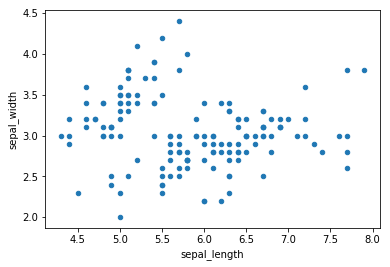

```python
#plotting a scatter plot with sepal length and sepal width of 150 species of the IRIS dataset.
iris.plot(kind='scatter',x='sepal_length',y='sepal_width')
plt.show()
```

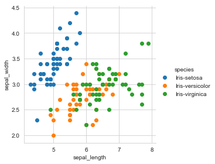

```python
sns.set_style("whitegrid");
sns.FacetGrid(iris,hue="species",height=4)\
   .map(plt.scatter,"sepal_length","sepal_width")\
   .add_legend();
plt.show();
```

# PAIR PLOT

```python
#paie wise scatter plot:pair plot
plt.close();
sns.set_style("whitegrid");
sns.pairplot(iris,hue="species",height=3);
plt.show()
```

[output not shown]

[output not shown]

# DRAWBACKS OF PAIRPLOT

Its efficient and easily to understand when the dimensions of dataset is small[In our case 4] If we have 100/1000 of dimensions its not efficient.

# OBSERVATIONS

1.Petal length and petal width are the most useful features to identify various flower types.

2.While setosa can be easily identified[linearly separable],versicolor and virginicia have some overlap[almost linearly separable]

# HISTOGRAMS

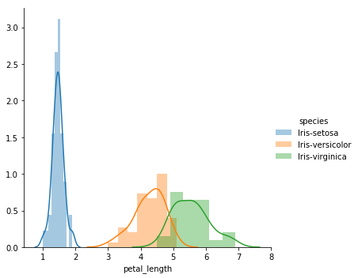

```python
sns.FacetGrid(iris,hue="species",height=5)\
   .map(sns.distplot,"petal_length")\
   .add_legend();
plt.show();
```

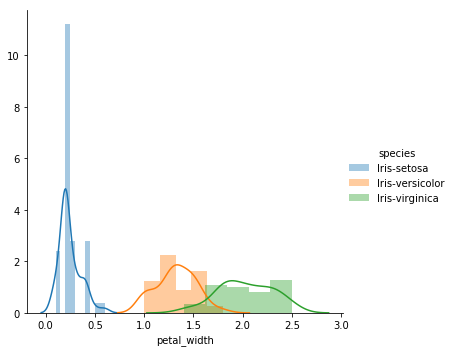

```python
sns.FacetGrid(iris,hue="species",height=5)\
   .map(sns.distplot,"petal_width")\
   .add_legend();
plt.show();
```

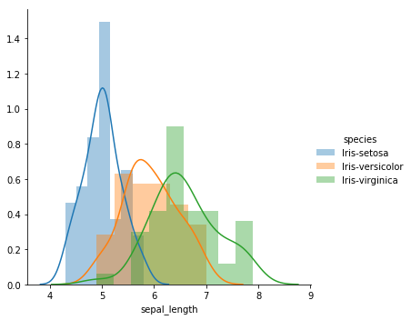

```python
sns.FacetGrid(iris,hue="species",height=5)\
   .map(sns.distplot,"sepal_length")\
   .add_legend();
plt.show();
```

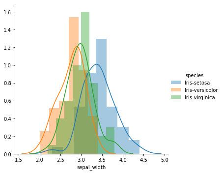

```python
sns.FacetGrid(iris,hue="species",height=5)\
   .map(sns.distplot,"sepal_width")\
   .add_legend();
plt.show();
```

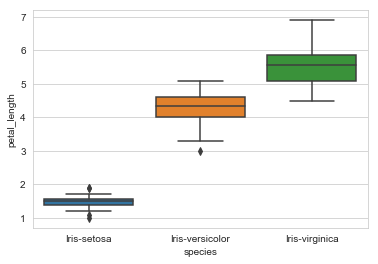

```python
sns.boxplot(x="species",y="petal_length",data=iris)
plt.show()
```

# VIOLIN PLOT

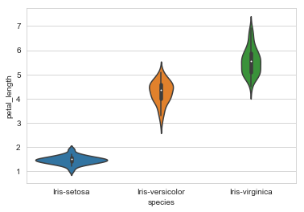

```python
sns.violinplot(x="species",y="petal_length",data=iris,height=8)
plt.show()
```

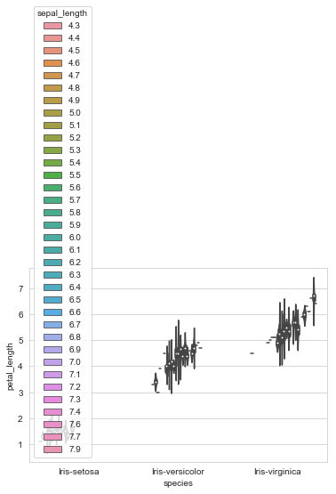

```python
sns.violinplot(x="species",y="petal_length",data=iris,height=8,hue="sepal_length")
plt.show()
```

# JOINTPLOTS

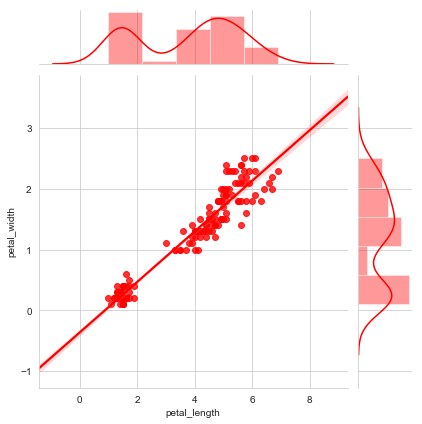

```python
sns.jointplot(x="petal_length",y="petal_width",data=iris , kind='reg',color='red')
```

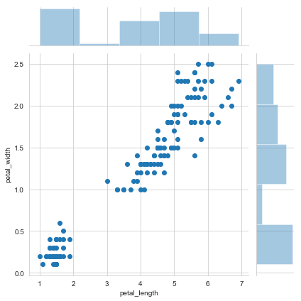

```python
sns.jointplot(x="petal_length",y="petal_width",data=iris )
```

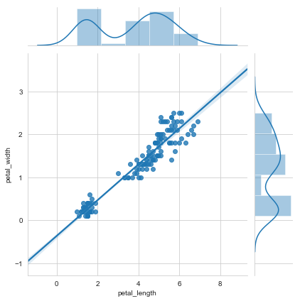

```python
sns.jointplot(x="petal_length",y="petal_width",data=iris , kind='reg')
```

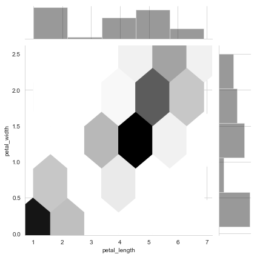

```python
sns.jointplot(x="petal_length",y="petal_width",data=iris , kind='hex',color='black')
```

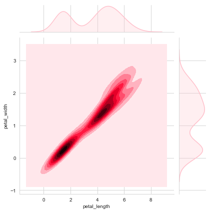

```python
sns.jointplot(x="petal_length",y="petal_width",data=iris , kind='kde',color='pink')
```

# MEANS AND MEDIANS

```python
print("means of petal length:")
print(np.mean(iris["petal_length"]))
```

```
means of petal length:
3.758666666666666
```

```python
print("means of petal width")
print(np.mean(iris["petal_width"]))
```

```
means of petal width
1.1986666666666668
```

```python
print("means of sepal length")
print(np.mean(iris["sepal_length"]))
```

```
means of sepal length
5.843333333333334
```

```python
print("means of sepal width")
print(np.mean(iris["sepal_width"]))
```

```
means of sepal width
3.0540000000000003
```

```python
print("median of petal length")
print(np.median(iris["petal_length"]))
```

[output not shown]

```python
print("median of petal width")
print(np.median(iris["petal_width"]))
```

```
median of petal width
1.3
```

```python
print("median of sepal length")
print(np.median(iris["sepal_length"]))
```

```
median of sepal length
5.8
```

```python
print("median of sepal width")
print(np.median(iris["sepal_width"]))
```

```
median of sepal width
3.0
```